# Vignette of XMLs

Michael DeWitt, Daniel Sebastian, Eunyoung Song

9/23/2018

# XML

*XML* stands for E**x**tensible **M**arkup **L**anguage and it was designed as a structured way to share data. Because the data exist in a software/ hardware indepdent format this format allows for exchange between users.[^1] It it because of this platform indepdence and human and machine readable nature that XML documents are often used as the payload for API calls.[^2] This means that a user can request data via an API and an XML will be supplied in return. Adlditionally, there is an hierarchical format for XML documents which are broken into *nodes*. Nodes provide structure with subsequent *child* and *sibling* nodes which represent elements deeper in the hierarchy. Additionally, the *attributes* within the nodes contain the actual values. Tags provide the name of the node and are denoted as follows:

- start tag as `<section>`
- end tag as `</section>`
- empty element as `<line-break />`

*Xpath*s can be used to navigate within an XML document. Knowing the `xpath` of an item will allow for easy querying and retrieval of the desired document within the `xpath`

XML is a good way to communicate data because it is platform indepdent making it good for use in APIs. Additionally, it is human readable so that adds for some power for record checking. There is the ability to put comments into XML via specific document tabs which allows for more meta-data.

# Discuss Packages with Pros and Cons

There are two major packages that are useful for parsing XML type documents. There is the older `XML` package and the newer (circa 2015) `xml2`. Both packages have similar functions and capabilties for parsing XML type documents. `XML` is the more comphrensive of the two packages, but it has a higher learning curve. Additionally, while piping and tidy principles can be applied using the `XML` package, the `xml2` package was designed by Hadley Whickham and Jim Hester of RStudio with the *tidy* programming paradigm in mind. The `XML` package only depends on base packages While the package isn’t quite as comphrensive (fewer functions) most of the main operations can be completed and the syntactic “tidyverse” sugar makes it easy to accomplish familiar tasks (e.g. `read_xml`).

*We can use the cran pageviews to research this* [here](https://cran.r-project.org/web/views/WebTechnologies.html)

Following our general preference for working in the tidyverse programming paradigm, we will use the `xml2` package. This will allow for optimised ussage of the pipe and tidy data frames.

# An Example

This example will use data that is available from data.gov, a website of the United States government for sharing public data. For the sake of this example an XML file was downloaded from the website regarding National Endowment for the Humanities grant applications and awards for the decade of the 2010s.

```r
url <- "https://securegrants.neh.gov/open/data/"

raw <- read_xml("data/NEH_Grants2010s.xml")

children <- xml_contents(raw)
```

After reading this data set into memory we can see that we need to design a parser that combines the XML nodes into a tidy data frame. This can be done by writing a function that looks for the xpath within the XML document, find the nodes, parses those nodes and then combines all of our outputs into a data frame that is returned by the function.

```r
parse_grant_data <- function(df){

  if(!attributes(df)$class[[1]] %in% c("xml_node", "xml_document")){
    stop("Not an XML class object")
  }

  applicant_type <- df %>%
  xml_find_all("//ApplicantType") %>%
  xml_text()

  institution <- df %>%
  xml_find_first("//Institution") %>%
  xml_text()

  org_type <- df %>%
  xml_find_all("//OrganizationType") %>%
  xml_text()

  inst_city <- df %>%
  xml_find_all("//InstCity") %>%
  xml_text()

  inst_state <- df %>%
  xml_find_all("//InstState") %>%
  xml_text()

  lat <- suppressWarnings(df %>%
  xml_find_all("//Latitude") %>%
  xml_text() %>%
    as.numeric())

  lon <- suppressWarnings(df %>%
  xml_find_all("//Longitude") %>%
  xml_text() %>%
    as.numeric())

  congress_district <- df %>%
  xml_find_all("//CongressionalDistrict") %>%
  xml_text()

  division <- df %>%
  xml_find_all("//Division") %>%
  xml_text()

  year_awarded <- df %>%
  xml_find_all("//YearAwarded") %>%
  xml_text() %>%
    as.numeric()

  approved_award <- df %>%
    xml_find_all("//AwardOutright") %>%
    xml_text() %>%
    as.numeric()

  award_matching <- df %>%
  xml_find_all("//AwardMatching") %>%
  xml_text() %>%
    as.numeric()

  approved_matching <- df %>%
  xml_find_all("//ApprovedMatching") %>%
  xml_text() %>%
    as.numeric()

  original_amount <- df %>%
    xml_find_all("//OriginalAmount") %>%
    xml_text() %>%
    as.numeric()

  out <- data_frame(applicant_type =applicant_type,
              institution = institution,
              org_type = org_type,
              inst_city = inst_city,
              inst_state = inst_state,
              congress_district = congress_district,
              lat = lat,
              lon = lon,
              division = division,
              year_awarded = year_awarded,
              approved_award = approved_award,
              award_matching = award_matching,
              approved_matching = approved_matching,
              original_amount = original_amount)
  out

}
```

## data with two categorical and two continuous

```r
df_1 <- parse_grant_data(raw)
```

## include a custom function

## create a new variable

```r
df_2 <- df_1 %>%
  mutate(total_award = approved_award + award_matching,
         perc_of_ask = original_amount/total_award)
```

## create a contingency table

```r
table(df_2$org_type, df_2$division)
```

```
##
##                                                Agency-wide Projects
##   Academic Library                                                0
##   Anthropology/Archaeology Museum                                 0
##   Archives                                                        0
##   Art Museum                                                      0
##   Arts Related Organizations                                      0
##   Center For Advanced Study/Research Institute                    0
##   Community-Level Organization                                    0
##   Educational Consortium                                          0
##   Elementary/Middle School                                        0
##   Four-Year College                                               0
##   General Museum                                                  0
##   Historic Preservation Organization                              0
##   Historical Site/House                                           0
##   Historical Society                                              0
##   History Museum                                                  0
##   Independent Production Company                                  0
##   Independent Research Library                                    0
##   Indian Tribal Organization                                      0
##   Libraries                                                       0
##   Museums                                                         0
##   National Organization                                           5
##   Natural History Museum                                          0
##   Nature Center/Botanical Garden/Aboretum                         0
##   Non-Profit Educational Center                                   0
##   None                                                            8
##   Philanthropic Foundation                                        0
##   Professional Association                                        0
##   Professional School                                             0
##   Public Library                                                  0
##   Publishing                                                      0
##   Radio Station                                                   0
##   School District                                                 0
##   Science and Technology Museum                                   0
##   State Department of Education                                   0
##   State Humanities Council                                        0
##   State/Local/Federal Government                                  0
##   Television/Station                                              0
##   Two-year College                                                0
```

[output cut: 289 more lines]

```
##   Professional Association                                     3
##   Professional School                                          1
##   Public Library                                               3
##   Publishing                                                 108
##   Radio Station                                                0
##   School District                                              0
##   Science and Technology Museum                                0
##   State Department of Education                                0
##   State Humanities Council                                     1
##   State/Local/Federal Government                               2
##   Television/Station                                           0
##   Two-year College                                            40
##   University                                                 847
##   University Museum                                            0
##   Unknown                                                      3
```

## create some plots

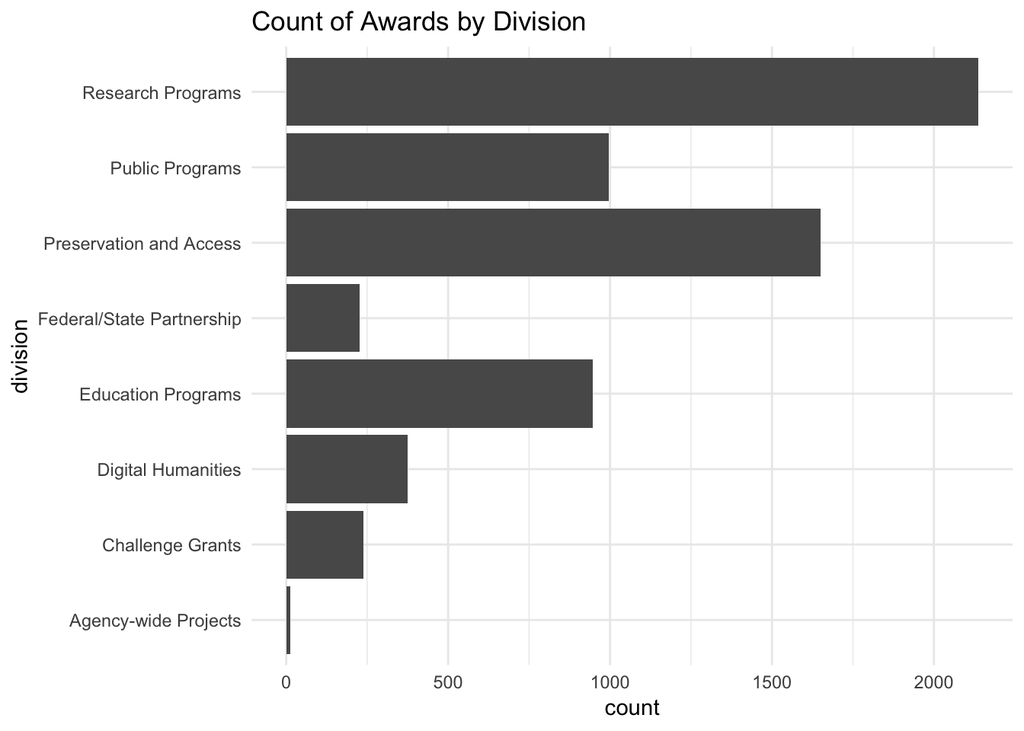

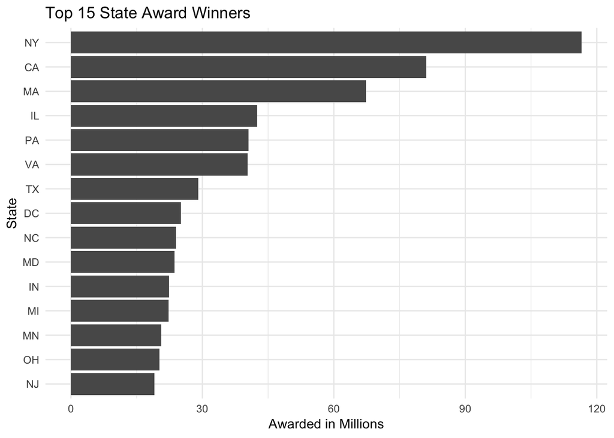

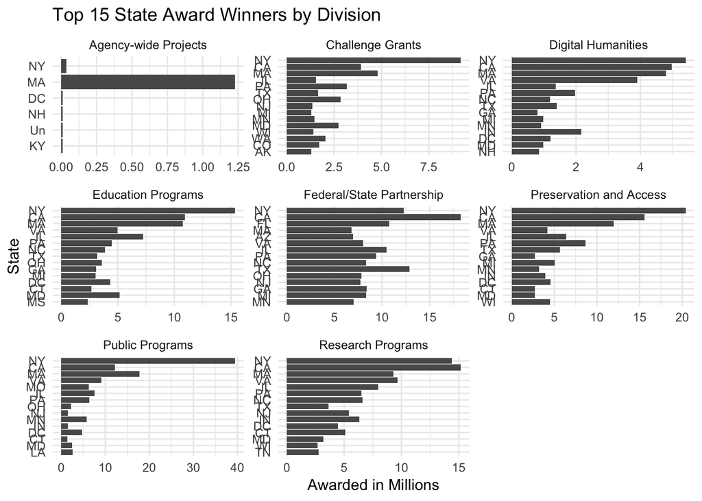

[^1]: “https://www.w3schools.com/xml/xml_whatis.asp”
[^2]: “https://en.wikipedia.org/wiki/XML”